# Project 3: Hadoop – HDFS- Sqoop -HIVE

**Dataset**: Yellow Taxicabs

By: **Siny P Raphel**

Pandas and numpy are packages widely used for data analysis and transformations. But these packages fail when the size of the data is large like in a few gigabytes or millions of rows. Therefore hadoop was introduced, which has the features of distributed storage systems and paralell processing. Map reduce is a technology which implements paralell processing. In mapreduce, Mapper functions carry out the execution part and reducers aggregates the outputs of mappers. But these mapreduce functions are complex to write even a simple program. Therefore hive is introduced. It works on map-reduce technology but we can write program as a simple SQL query. One of the drawback of hadoop/hive is that data cannot be transfered directly to andn from relational databases. Another tool called sqoop is used to transfer data from relational database to hdfs/hive and viseversa. The goal of this project is to demonstrate how data is transfered between hadoop and mysql and finally hive is used for the analysis. The dataset is a csv file with taxi trip details which consist of 10k rows and 19 features.

## Steps for data transfer from mysql to hive

### Step 1: Local system to hadoop local system

The csv file in my local system is transfered to local hadoop system with the help of the tool winSCP.

### Step 2: Hadoop system to mysql database

First I created a mysql table with the schema same as the given data as shown below

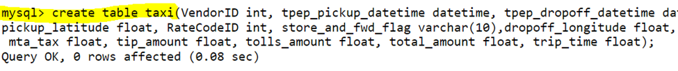

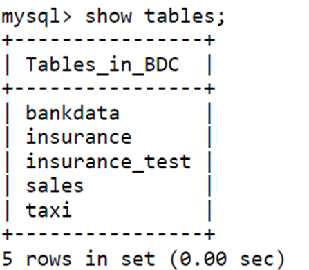

Following is the schema of the created table - taxi:

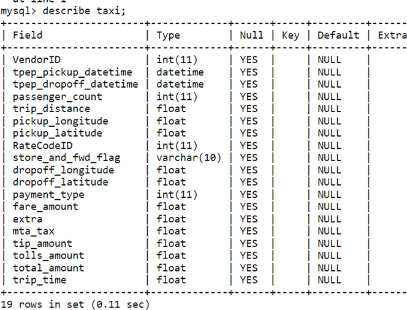

Now the data in the csv file has to be transfered to the mysql db and is done using the following code.

load data local infile '/root/yellow_tripdata_2015-01-06.csv' into table taxi FIELDS TERMINATED BY "," ENCLOSED BY "" LINES TERMINATED BY "\n" IGNORE 1 ROWS;

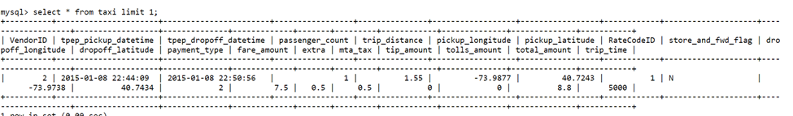

### Step 3: Mysql to hive table

Now since we got the whole data in mysql we have to transfer these data to our hive table. For this we use the sqoop tool. The code is as follows:

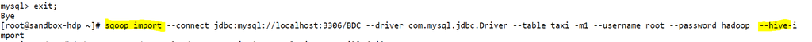

The following Figure shows that the table taxi is successfully entered to hive table – taxi.

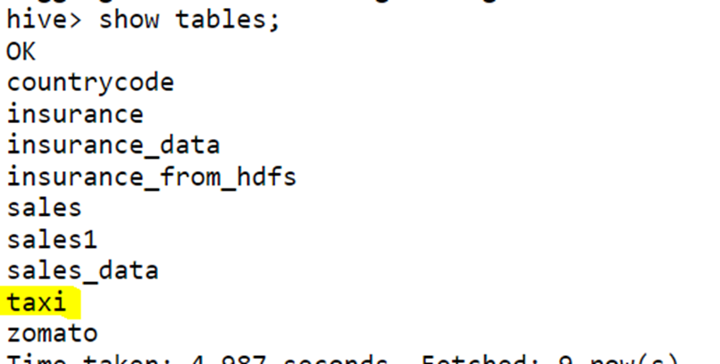

## Analysis of taxi table

### Questions

1. What is the total number of trips (equal to the number of rows)?

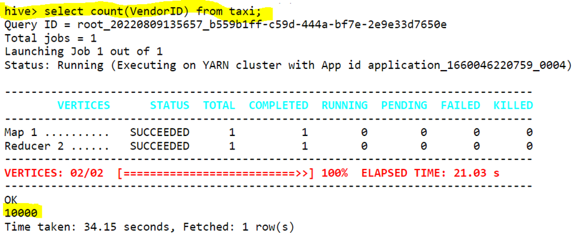

Total number of trips calculated by counting the number of rows in the table

1. What is the total revenue generated by all the trips?

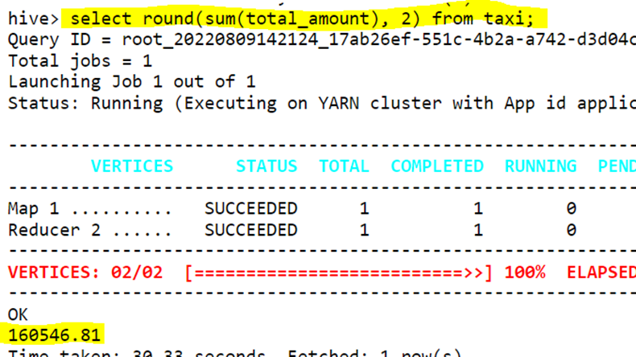

Total revenue is calculated by adding the total_amt field

1. What fraction of the total is paid for tolls?

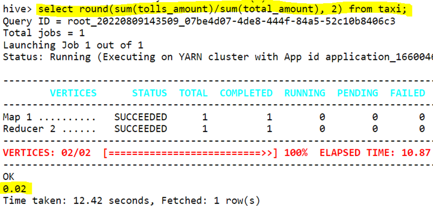

Calculted by dividing the total tolls_amount by sum of total_amount

1. What fraction of it is driver tips?

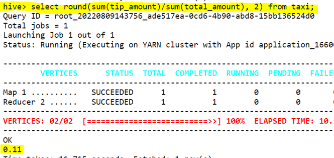

Calaculated fraction by dividing the total tip_amount with the sum of total_amount

1. What is the average trip amount?

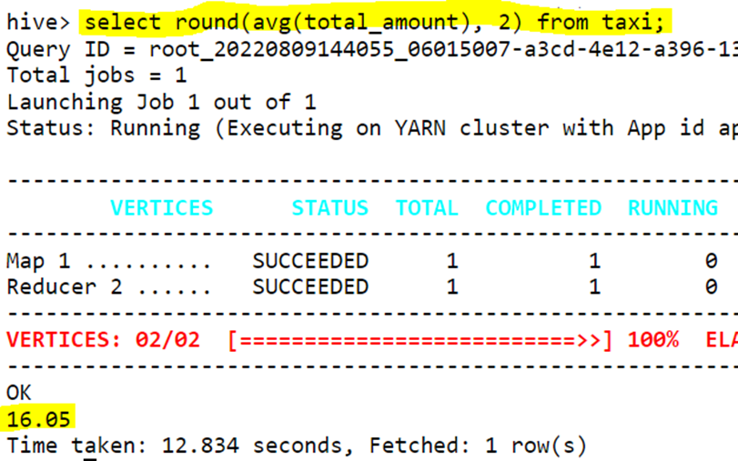

Calaculated the average of total_amount

1. What is the average distance of the trips?

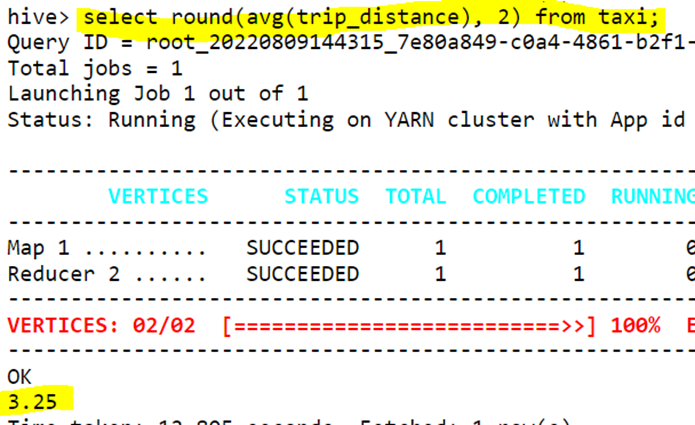

Calculated the average value of trip_distance and rounded to two decimal values

1. How many different payment types are used?

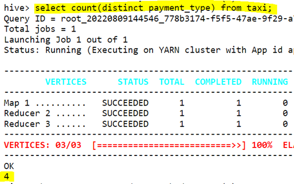

Here I retrieved the count of distinct payment_types

1. For each payment type, display the following details:
- Average fare generated
- Average tip
- Average tax

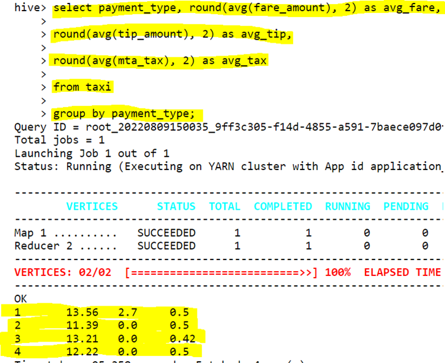

In this, I grouped the data wrt payment_type and then calculated the average values of fare amount, tip amount and tax

1. On average which hour of the day generates the highest revenue?

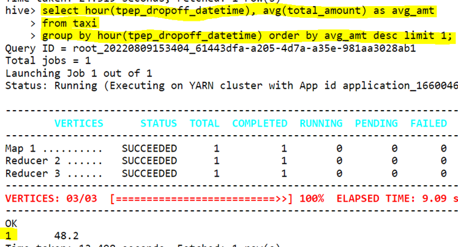

In this question I grouped the data with respect to the hour of dropoff times and then ordered by average total_amount in descending order. Later the first row is retrieved which gave the hour of the highest average revenue